# Predicting Loan Defaults with Logistic Regression

Riley Heiman

November 13, 2018

# Part 1

### Executive Summary

This report provides an analysis and evaluation of the current profitability model for World Bank. Every customer has a specific set of characteristics. These include employment status, current job role, a reason for the loan, geographic location/address, credit history (`grade`), number of open credit lines, number of derogatory public records including bankruptcy filings, tax liens, and many other similar characteristics as well.

One of the most significant expenses here at World Bank is the increasing amount of defaulting loans! How can we better *predict* whether or not someone will default on a loan ahead of time? Within a certain degree of accuracy, this model can make these predictions using some of the characteristics listed above.

By withholding a portion of the data during the model generation, we were able to test the accuracy of this model. In short, we found that the model can accurately predict a “good” loan v.s. “bad” loans, almost *80%* of the time.

### Introduction

Hello,

This data set has exactly 50,000 previous loans and 32 variables associated with each one. Please note, Total Paid *(“totalPaid”)* cannot be one of our predictor variables, because this cannot be determined when clients initially apply for loans. This document will outline each stage of the model generation process and notes along the way. If any questions should arise please reach out to the Advanced Analytics team.

Riley Heiman

*-Data Scientist*

### Preparing and Cleaning the data

Load Required Packages

```r
library(ggformula)
library(ggplot2)
library(dplyr)
library(moments)
library(xlsx)
library(plotly)
library(ROCR)
```

*First we must remove any NA results*

```r
#The code below will remove any NA's from our data frame.
credit = na.omit(credit)
```

*Second we must change our response variable to the follwoing*

| Previous “Status” Value | Changed to….. |
| --- | --- |
| Charged off | “Bad” |
| Default | “Bad” |
| Fully Paid | “Good” |
| Current | *removed from data frame* |
| In Grace Period | *removed from data frame* |
| Late (16-30 days) | *removed from data frame* |
| Late (31-120 days) | *removed from data frame* |
| Blank / NA values | *removed from data frame* |

```r
credit =
  credit %>%
  mutate(status = case_when(
    status == "Charged Off" |status == "Default" ~1,
    status == "Fully Paid"~ 0,
    status == "Current" | status == "In Grace Period"| status == "Late (16-30 days)" | status == "Late (31-120 days)" ~ 2
    #TRUE ~ "Something is wrong"
  ))

credit[, 'status'] <- as.factor(credit[, 'status'])

summary(credit$status)
```

```
##     0     1     2
## 26767  7504 15208
```

```r
#This table in important because it show how many are "Good" "Bad" and how many should be removed.
```

*Please note….*

| Value | Name |
| --- | --- |
| 0 | “Good” |
| 1 | “Bad” |
| 2 | “Remove” |

We have successfully re-factored our status variable into three categories above. Now we must remove the third category “Remove” from our data using the code below.

```r
# This will remove all oberservations that have the "Remove" label for the status variable.
#credit$status = credit$status[!is.na(credit$status)]
toBeRemoved<-which(credit$status==2)
credit<-credit[-toBeRemoved,]
credit$status = factor(credit$status)
summary(credit$status)
```

```
##     0     1
## 26767  7504
```

Here we can see that he have retained all of our Bad and Good loan status values, but any loan label “Remove” has been deleted! Next we must re-categorize our variable “reason”. Many of the variables have a low number of observations, so we can collect these together into one category called “other”

Please see the code below for refrence.

```r
summary(credit$reason)
```

```
##                                   car        credit_card
##                  0                277               7797
## debt_consolidation   home_improvement              house
##              20827               1986                123
##     major_purchase            medical             moving
##                609                369                209
##              other   renewable_energy     small_business
##               1527                 27                313
##           vacation            wedding
##                205                  2
```

```r
credit =
  credit%>%
  mutate(reason = case_when(
    reason == "house" | reason=="car" | reason =="home_improvement" | reason == "major_purchase" | reason == "medical" | reason == "moving" | reason == "other" | reason == "renewable_energy" | reason == "small_business" | reason == "vacation" | reason == "wedding" ~ "other",
    reason == "credit_card"~"credit_card",
    reason == "debt_consolidation"~"debt_consolidation"
    ))

credit[, 'reason'] <- as.factor(credit[, 'reason'])

# This will combine our variables into 3 categories.
```

Lastly, we can note the total number of observations removed.

```r
a = 50000-dim(credit)[1]

print(paste(c("Total number of observations removed is   ",a),collapse = ''))
```

```
## [1] "Total number of observations removed is   15729"
```

### Exploring and Transforming the data

```r
#View(sub_credit)

credit_avg =
  credit%>%
  group_by(status)%>%
  summarise(meanAmount=mean(amount))

#gf_col(meanAmount~status,data = credit_avg)
print(credit_avg)
```

```
## # A tibble: 2 x 2
##   status meanAmount
##   <fct>       <dbl>
## 1 0          14417.
## 2 1          15466.
```

We can see in the table above that the average amount for Bad loans is 15466.09 and 14417.09 for good loans. Is there sufficient evidence to claim that bad loans have a greater amount then good loans? Let’s find out by running a Welch Two Sample t-test!

$$H_0: {\mu_{Bad}} < {\mu_{Good}}$$

$$H_a: {\mu_{Bad}} \geq {\mu_{Good}}$$

```r
bad = credit$amount[credit$status==1]
good = credit$amount[credit$status==0]
mean(bad)
```

```
## [1] 15466.09
```

```r
mean(good)
```

```
## [1] 14417.09
```

```r
t.test(bad,good,alternative = "greater")
```

```
##
##  Welch Two Sample t-test
##
## data:  bad and good
## t = 9.5399, df = 12110, p-value < 2.2e-16
## alternative hypothesis: true difference in means is greater than 0
## 95 percent confidence interval:
##  868.1193      Inf
## sample estimates:
## mean of x mean of y
##  15466.09  14417.09
```

We have found a p-value $< {\alpha = .05}$. In the situation we must reject the null and accept the alternative. In other words, there is sufficent evidence to claim that the average credit amount for “Bad” loans are greater then “Good” loans! This is a significant finding for our results, because it enhances the importance of generating a strong predictive model.

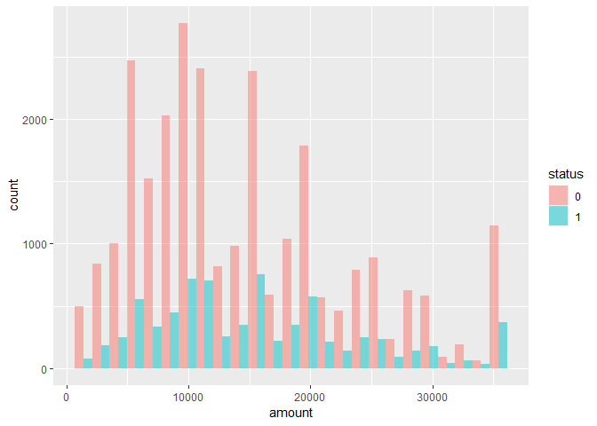

```r
credit%>%
  gf_histogram(~amount,data=credit,fill=~status,position = PositionDodge)
```

```r
summary(credit$status)
```

```
##     0     1
## 26767  7504
```

Additonally, we can see in the histogram above and the summary table that the total number of “Good” loans far exceedes the “Bad” loans. Almost 80% of loans are considered good. Moving forward, this will be a good target for us to hit in terms of our accuracy level. Accepting more bad loans could imply a loss in revune for the company.

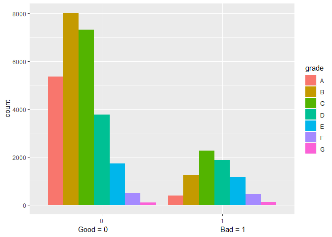

```r
gf_bar(~status,fill=~grade,position=position_dodge(),data=credit) + xlab(c("Good = 0                                                         Bad = 1"))
```

In order to understand the relationship between grade and status we have a bar chart above. Although the diagram is not normalized, we do however see the Good distribution is right skewed. The Bad distribution is more normal.

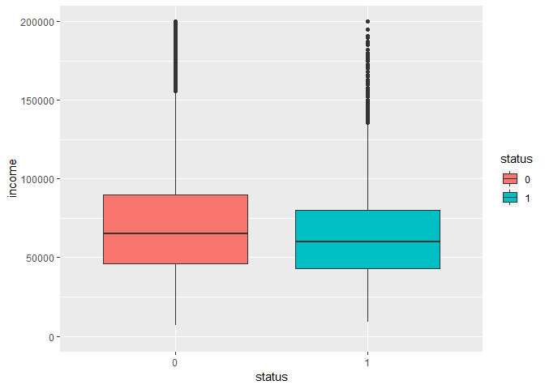

```r
#y1 = credit$income[credit$status=="Bad"]
#y2 = credit$income[credit$status=="Good"]

credit%>%
  gf_boxplot(income~status,fill = ~status)%>%
  gf_lims(y=c(0,200000))
```

The boxplot above shows us that the income level for a particular client is generally the same for Bad and Good. All of these plots help us to determine which variables to include as predictor variables for our logistic regression.

# Part 2

### The Logistic Model

There are many variables within our data frame and only certain ones may be most valuable to us. We can run the glm() function and analyze the p-values associated with each predictor variable. Recall, we are testing:

$$H_0 : {\beta_i} = 0$$

$$H_a : {\beta_i} \neq 0$$

```r
summary(glm.out)
```

```
##
## Call:
## glm(formula = status ~ amount + term + rate + grade + verified +
##     reason + debtIncRat + delinq2yr + inq6mth + totalRevLim +
##     accOpen24 + totalLim + totalRevBal + totalIlLim, family = "binomial",
##     data = credit)
##
## Deviance Residuals:
##     Min       1Q   Median       3Q      Max
## -1.7967  -0.7308  -0.5211  -0.3088   4.1598
##
## Coefficients:
##                            Estimate Std. Error z value Pr(>|z|)
## (Intercept)              -3.127e+00  1.141e-01 -27.401  < 2e-16 ***
## amount                    7.502e-06  2.120e-06   3.539 0.000402 ***
## term 60 months            5.701e-01  3.572e-02  15.962  < 2e-16 ***
## rate                      2.652e+00  1.215e+00   2.182 0.029092 *
## gradeB                    4.032e-01  7.401e-02   5.448 5.09e-08 ***
## gradeC                    8.008e-01  9.739e-02   8.222  < 2e-16 ***
## gradeD                    9.961e-01  1.338e-01   7.447 9.53e-14 ***
## gradeE                    1.089e+00  1.652e-01   6.593 4.30e-11 ***
## gradeF                    1.179e+00  2.193e-01   5.378 7.54e-08 ***
## gradeG                    1.260e+00  2.764e-01   4.558 5.17e-06 ***
## verifiedSource Verified   9.654e-02  3.636e-02   2.655 0.007924 **
## verifiedVerified          1.143e-01  3.956e-02   2.890 0.003855 **
## reasondebt_consolidation -6.758e-02  3.615e-02  -1.870 0.061520 .
## reasonother              -1.211e-02  4.815e-02  -0.252 0.801366
## debtIncRat                2.535e-02  1.847e-03  13.727  < 2e-16 ***
## delinq2yr                 6.557e-02  1.492e-02   4.396 1.10e-05 ***
## inq6mth                   3.651e-02  1.419e-02   2.573 0.010081 *
## totalRevLim              -5.731e-06  9.039e-07  -6.340 2.29e-10 ***
## accOpen24                 6.065e-02  4.607e-03  13.166  < 2e-16 ***
## totalLim                 -1.381e-06  1.246e-07 -11.081  < 2e-16 ***
## totalRevBal               6.236e-06  1.046e-06   5.964 2.46e-09 ***
## totalIlLim               -7.181e-06  1.096e-06  -6.550 5.75e-11 ***
## ---
## Signif. codes:  0 '***' 0.001 '**' 0.01 '*' 0.05 '.' 0.1 ' ' 1
##
## (Dispersion parameter for binomial family taken to be 1)
##
##     Null deviance: 36025  on 34270  degrees of freedom
## Residual deviance: 32421  on 34249  degrees of freedom
## AIC: 32465
##
## Number of Fisher Scoring iterations: 5
```

Everytime we have a p-value $< {\alpha} = .05$ then we must reject the null hypothesis and accept the alternative. In other words, the table above shows a *majority* of variables where ${\beta_i} \neq 0$ . We have sufficent evidence to believe the ${\beta}$ estimates associated with each variable.

Please note, the best model selected above was generated with the `step()` function. The results are not shown above, because the output can be very lengthy.

Now that we have identified the key predictor variables, we can move forward with building our logistic regression. This is done by subsetting our data into testing and training sets. The function `select_rand_int(n,c)` will allows us to randomly subset our data by generating random numbers.

- n = total number of observations in the data.
- c = constant. (i.e. what % of the data should be selected?) $where: 0<c<1$

```r
nrow = dim(credit)[1]
c = .80
random_subset = select_rand_int(nrow,c)
```

```
## [1] "Total Number of Observations Removed = 6854"
```

```r
#random_subset
train_credit = credit[random_subset,]
test_credit  = credit[-random_subset,]

test_credit$status = as.factor(test_credit$status)
train_credit$status = as.factor(train_credit$status)
```

### Optimizing the Threshold for Accuracy

Now that we have a random subset of our original data, we can now re-create the logistic regression with the same predictor variables, by selecting a subset generated from the step before.

```r
#summary output here.
summary(glm_test1)
```

```
##
## Call:
## glm(formula = status ~ amount + term + rate + grade + verified +
##     reason + debtIncRat + delinq2yr + inq6mth + totalRevLim +
##     accOpen24 + totalLim + totalRevBal + totalIlLim, family = "binomial",
##     data = train_credit)
##
## Deviance Residuals:
##     Min       1Q   Median       3Q      Max
## -1.8367  -0.7306  -0.5283  -0.3061   4.1525
##
## Coefficients:
##                            Estimate Std. Error z value Pr(>|z|)
## (Intercept)              -3.228e+00  1.274e-01 -25.340  < 2e-16 ***
## amount                    9.157e-06  2.361e-06   3.879 0.000105 ***
## term 60 months            5.309e-01  3.987e-02  13.314  < 2e-16 ***
## rate                      3.366e+00  1.349e+00   2.494 0.012616 *
## gradeB                    4.167e-01  8.257e-02   5.046 4.51e-07 ***
## gradeC                    7.523e-01  1.086e-01   6.929 4.22e-12 ***
## gradeD                    9.210e-01  1.491e-01   6.179 6.44e-10 ***
## gradeE                    1.002e+00  1.836e-01   5.458 4.83e-08 ***
## gradeF                    1.094e+00  2.436e-01   4.489 7.17e-06 ***
## gradeG                    1.233e+00  3.084e-01   3.999 6.36e-05 ***
## verifiedSource Verified   8.145e-02  4.052e-02   2.010 0.044388 *
## verifiedVerified          9.017e-02  4.407e-02   2.046 0.040725 *
## reasondebt_consolidation -5.913e-02  4.029e-02  -1.468 0.142166
## reasonother              -3.194e-02  5.388e-02  -0.593 0.553363
## debtIncRat                2.644e-02  2.069e-03  12.778  < 2e-16 ***
## delinq2yr                 7.758e-02  1.653e-02   4.694 2.68e-06 ***
## inq6mth                   2.909e-02  1.593e-02   1.826 0.067873 .
## totalRevLim              -5.718e-06  9.996e-07  -5.720 1.06e-08 ***
## accOpen24                 6.641e-02  5.126e-03  12.956  < 2e-16 ***
## totalLim                 -1.403e-06  1.395e-07 -10.053  < 2e-16 ***
## totalRevBal               5.917e-06  1.162e-06   5.092 3.55e-07 ***
## totalIlLim               -6.817e-06  1.224e-06  -5.570 2.55e-08 ***
## ---
## Signif. codes:  0 '***' 0.001 '**' 0.01 '*' 0.05 '.' 0.1 ' ' 1
##
## (Dispersion parameter for binomial family taken to be 1)
##
##     Null deviance: 28898  on 27416  degrees of freedom
## Residual deviance: 26030  on 27395  degrees of freedom
## AIC: 26074
##
## Number of Fisher Scoring iterations: 5
```

*Does this model make a good prediction?*

```r
threshold = .50

# Plese note, we are using our test data for prediction.
pred = predict(glm_test1,newdata = test_credit,type = "response")

# IF our prediciton result is greater then threshold,
# THEN set value = 1
# ELSE set value = 0
pred = ifelse(pred > threshold,1,0)
###################################

# THIS IS WHAT ACTUALLY HAPPEND.
test_check = test_credit$status

Error <- mean(pred != test_check)
print(paste(c("The error rate is..  ",round(Error*100,digits = 2)," %"),collapse = ''))
```

```
## [1] "The error rate is..  21.01 %"
```

*What if we had a different threshold?*

Lets test the model for threshold values 0 through 1.

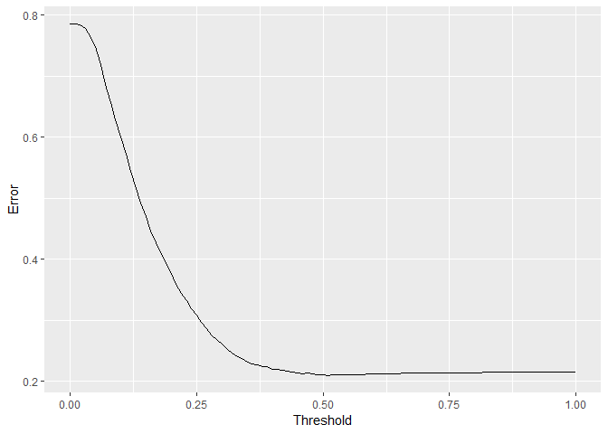

```r
seq = seq(0,1,.01)
error_array = NULL
j=1
for (i in seq) {
  pred = predict(glm_test1,newdata = test_credit,type = "response")
  pred = ifelse(pred > i,1,0)

  test_check = test_credit$status

  Error <- mean(pred != test_check)

  error_array[j] = Error
  j=j+1
}
data = as.data.frame(matrix(c(seq,error_array),ncol = 2))
colnames(data) = c("Threshold","Error")

ggplot(data = data,aes(x=Threshold, y=Error)) +
  geom_line()
```

The graph above shows theoretical threshold set from 0 to 1. The error rate represents how accurate our model is for a given threshold. In short, a threshold of .50 is ideal as a decision bountry.

### Optimizing the Threshold for Profit

Profit is maximized when the predicitons for Bad loans is highly accurate.

*At what threshold is profit maximized?*

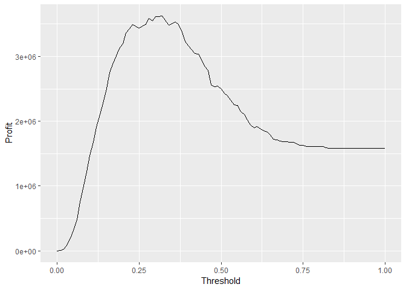

```r
pred = ifelse(pred > threshold,1,0)
index<-which(pred==0)
good_cases = test_credit[index,]
TOTAL_REVENUE = sum(good_cases$totalPaid)
###################################

seq = seq(0,1,.01)
error_array = NULL
Rev_array = NULL
j=1
for (i in seq) {
  pred = predict(glm_test1,newdata = test_credit,type = "response")
  pred = ifelse(pred > i,1,0)
  index<-which(pred==0)
  good_cases = test_credit[index,]
  TOTAL_REVENUE = sum(good_cases$totalPaid) - sum(good_cases$amount)
  Rev_array[j] = TOTAL_REVENUE

  j=j+1
}
data = as.data.frame(matrix(c(seq,Rev_array),ncol = 2))
colnames(data) = c("Threshold","Profit")

ggplot(data = data,aes(x=Threshold, y=Profit)) +
  geom_line()
```

### Results Summary

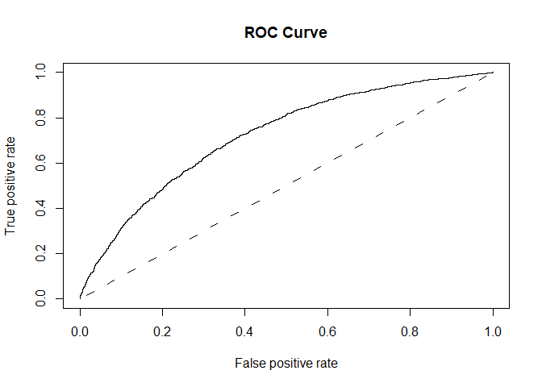

```r
pred = predict(glm_test1,newdata = test_credit,type = "response")
pr <- prediction(pred, test_credit$status)
prf <- performance(pr, measure = "tpr", x.measure = "fpr")
plot(prf,main = "ROC Curve")
lines(seq(0,1,.05),seq(0,1,.05),type = 'c',lwd=1.5)
```

```r
auc <- performance(pr, measure = "auc")
auc <- auc@y.values[[1]]
print(paste(c("The area under the curve is ",round(auc,digits = 3)),collapse = ''))
```

```
## [1] "The area under the curve is 0.722"
```